# A computational model of responsibility judgments from counterfactual simulations and intention inferences

Sarah A. Wu, Shruti Sridhar, and Tobias Gerstenberg

April 26, 2024

# 1 Setup

# 2 Helper functions

## 2.1 Demographics

```r
print_demographics = function(data) {
  # gender
  data %>%
    group_by(gender) %>%
    summarise(n = n()) %>%
    print()

  # age
  print('age:')
  mean(data$age, na.rm = T) %>% print()
  sd(data$age, na.rm = T) %>% print()

  # race
  data %>%
    group_by(race) %>%
    summarise(n = n()) %>%
    print()

  # ethnicity
  data %>%
    group_by(ethnicity) %>%
    summarise(n = n()) %>%
    print()

  # time taken
  print('time taken (min):')
  print(mean(data$time, na.rm = T)/60/1000)
  print(sd(data$time, na.rm = T)/60/1000)
}
```

## 2.2 Scatterplot

```r
scatterplot = function(data, x, x_label, y, y_label, point_fill = 'gray50') {

  r = cor(data[[paste0(x, "_mean")]], data[[paste0(y, "_mean")]]) %>%
    round(2)
  rmse = rmse(data[[paste0(x, "_mean")]], data[[paste0(y, "_mean")]])

  g = ggplot(data = data,
             aes(x = get(paste0(x, "_mean")),
                 y = get(paste0(y, "_mean")))) +
    geom_abline(intercept = 0, slope = 1,
                linetype = 2, size = 0.2) +
    # error bars
    geom_linerange(size = 0.5,
                   mapping = aes(ymin = get(paste0(y, "_low")),
                                 ymax = get(paste0(y, "_high"))),
                   color = 'lightgray') +
    geom_errorbarh(mapping = aes(xmin = get(paste0(x, "_low")),
                                 xmax = get(paste0(x, "_high"))),
                     color = 'lightgray',
                     height = 0) +
    # means
    geom_point(shape = 21, size = 3, stroke = 0.1, fill = point_fill) +
    geom_text(label = sprintf('RMSE = %.2f\nr = %s', rmse, r),
              hjust = 0,   # left align
              x = 0, y = 95,
              size = 5, check_overlap = T) +
    scale_x_continuous(name = x_label,
                       limits = c(0, 100)) +
    scale_y_continuous(name = y_label,
                       limits = c(0, 100)) +
    theme(legend.position = "none",
          text = element_text(size = 16),
          axis.title.x = element_markdown(size = 15),
          axis.title.y = element_markdown(size = 15))

  return(g)
}
```

## 2.3 Barplot

Experiment conditions:

```r
conditions = c('cf', 'int', 'effort', 'resp', 'resp_blue', 'resp_red')

condition_labels = c('cf' = 'counterfactual',
                     'int' = 'intention',
                     'effort' = 'effort',
                     'resp' = 'responsibility',
                     'resp_blue' = 'responsibility (blue)',
                     'resp_red' = 'responsibility (red)')

condition_colors = c('cf' = 'orchid3',
                     'int' = 'tan2',
                     'effort' = 'aquamarine3',
                     'resp' = 'deepskyblue',
                     'resp_blue' = 'deepskyblue',
                     'resp_red' = 'brown1')
```

Explanation features:

```r
features = c('box', 'time', 'red_actions', 'red_mental', 'blue_actions', 'blue_mental')

feature_labels = c('box' = 'box',
                   'time' = 'time',
                   'red_actions' = 'red actions',
                   'red_mental' = 'red mental',
                   'blue_actions' = 'blue actions',
                   'blue_mental' = 'blue mental')

feature_colors = c('box' = 'gray90',
                   'time' = 'gray60',
                   'red_actions' = 'salmon',
                   'red_mental' = 'brown1',
                   'blue_actions' = 'lightskyblue1',
                   'blue_mental' = 'deepskyblue')
```

```r
barplot = function(data.all, data.models, labels) {
  fill_values = condition_colors[names(condition_colors) %in% data.models$condition]
  fill_labels = condition_labels[names(condition_labels) %in% data.models$condition]

  g = ggplot(data = data.all,
             mapping = aes(x = condition,
                           y = judgment,
                           fill = condition)) +
    stat_summary(fun = "mean",
                 geom = "bar",
                 color = "black",
                 alpha = 0.8,
                 size = 0.1) +
    stat_summary(fun.data = mean_cl_boot,
                 geom = "linerange",
                 color = "black") +
    geom_point(size = 0.1,
               shape = 21,
               color = 'gray40',
               position = position_jitter(height = 0, width = 0.2),
               show.legend = F) +
    geom_point(data = data.models,
               mapping = aes(y = prediction),
               size = 3,
               shape = 21,
               show.legend = F) +
    geom_custom(data = labels %>%
                  mutate(condition = NA),
                mapping = aes(data = grob,
                              x = -Inf, y = Inf),
                grob_fun = function(x) rasterGrob(x,
                                                  interpolate = T,
                                                  vjust = 0,
                                                  hjust = 0,
                                                  height = unit(3.8, 'cm'))) +
    geom_text(aes(label = trial_label,
                  x = 0.6, y = 126),
              color = 'black',
              size = 7,
              hjust = 0,
              check_overlap = T) +
    facet_wrap(~ trial, nrow = 1, scales = 'free_x') +
    guides(fill = guide_legend(nrow = 1)) +
    scale_fill_manual(values = fill_values,
                      labels = fill_labels) +
    scale_y_continuous(name = 'judgment',
                       breaks = seq(0, 100, 25),
                       expand = expansion(mult = 0.01)) +
    coord_cartesian(clip = "off",
                    ylim = c(0, 110)) +
    theme(text = element_text(size = 16),
          legend.position = 'bottom',
          legend.direction = 'horizontal',
          legend.text = element_text(
            margin = margin(r = 0.5, unit = 'cm')),
          axis.title.x = element_blank(),
          axis.text.x = element_blank(),
          axis.line.x = element_blank(),
          axis.ticks.x = element_blank(),
          strip.background = element_blank(),
          strip.text = element_blank(),
          panel.grid.major.y = element_line(),
          plot.margin = margin(t = 3.9, l = 0.2,
                               r = 0.2 , b = 0.2, unit = 'cm'))
  print(g)
}
```

# 3 Experiment 1

```r
data_dir = '../data/experiment1/'
figures_dir = '../figures/experiment1/'
info_dir = '../model/experiments/experiment1/'
```

## 3.1 Data

### 3.1.1 Trial info

```r
trials.exp1 = c(1, 9, 14, 16, 17, 21, 23, 24)

info.exp1 = read_csv(paste0(info_dir, 'models.csv'),
                     show_col_types = F) %>%
  rename(cf_model = cf_success_rate,
         int_model = numerical_intention,
         effort_model = blue_effort) %>%
  mutate(outcome = factor(outcome, levels = c('success', 'fail')),
         trial_label = c(1, NA, NA, NA, NA, NA, NA, NA,
                         2, NA, NA, NA, NA, 3, NA, 4,
                         5, NA, NA, NA, 6, NA, 7, 8),
         ) %>%
  left_join(read_csv(paste0(info_dir, 'heuristics.csv'),
                     show_col_types = F),
            by = 'trial')
```

### 3.1.2 Counterfactual condition

#### 3.1.2.1 Response data

```r
data.exp1.cf = read_csv(paste0(data_dir, 'counterfactual/trials.csv'),
                        show_col_types = F) %>%
  rename(id = workerid) %>%
  drop_na(trial) %>%
  left_join(info.exp1 %>% select(trial, outcome),
            by = 'trial') %>%
  mutate(id = factor(id),
         plot_id = as.factor(as.integer(id)),
         cf_recode = ifelse(outcome == 'success', 100 - cf, cf))
```

Number of participants:

```r
length(unique(data.exp1.cf$id))
```

```
## [1] 50
```

#### 3.1.2.2 Participant data

Participants were asked: “What factors influenced how you decided to respond? Do you have any questions or comments regarding the experiment?”

```r
participants.exp1.cf = read_csv(paste0(data_dir, 'counterfactual/participants.csv'),
                                show_col_types = F) %>%
  rename(id = workerid) %>%
  mutate(id = factor(id)) %>%
  merge(data.exp1.cf %>%
          distinct(id, plot_id),
        by = 'id')

participants.exp1.cf %>%
  select(plot_id, feedback) %>%
  datatable(rownames = F)
```

| plot_id | feedback |
| --- | --- |
| 1 | If the red player had a path it could take to make to the star in the limited amount of steps to win the round. If there were boxes in the way then the blue player mattered. |
| 2 |  |
| 3 | no |
| 4 | The restrictions on red and the blocks and walls near or around the star |
| 5 | If the red player could have gotten to the star in 10 moves without the blue player on the board to change anything about the layout, I agreed that the red player would succeed without blue there, reg… |
| 6 | Whether or not the star was blocked from the beginning with zero chance of reaching it. |
| 7 | I tried to count how many squares it would take the red guy (and imagine the obstacles as they stood without the blue guy) when deciding if he might have succeeded or not. |
| 8 | My responses were based on whether I could calculate a path that led to the star within the set number of moves available. I think I was faster to state that the red player would not have succeeded if… |
| 9 | If the red player could make it to the star within ten seconds, then it could have been successful without the blue player. |
| 10 |  |

[output cut: 40 more lines]

### 3.1.3 Intention condition

#### 3.1.3.1 Response data

```r
data.exp1.int = read_csv(paste0(data_dir, 'intention/trials.csv'),
                         show_col_types = F) %>%
  rename(id = workerid) %>%
  drop_na(trial) %>%
  left_join(info.exp1 %>% select(trial, outcome),
            by = 'trial') %>%
  mutate(id = factor(id),
         plot_id = as.factor(as.integer(id)),
         int_recode = ifelse(outcome == 'success', int, 100 - int))
```

Number of participants:

```r
length(unique(data.exp1.int$id))
```

```
## [1] 50
```

#### 3.1.3.2 Participant data

Participants were asked: “What factors influenced how you decided to respond? Do you have any questions or comments regarding the experiment?”

```r
participants.exp1.int = read_csv(paste0(data_dir, 'intention/participants.csv'),
                                    show_col_types = F) %>%
  rename(id = workerid) %>%
  mutate(id = factor(id)) %>%
  merge(data.exp1.int %>%
          distinct(id, plot_id),
        by = 'id')

participants.exp1.int %>%
  select(plot_id, feedback) %>%
  datatable(rownames = F)
```

| plot_id | feedback |
| --- | --- |
| 1 |  |
| 2 | Looking to see how the blue player responded to the red player movements. |
| 3 | the motion of the blue player in relation to clearing the shortest path for the red player to reach the star |
| 4 |  |
| 5 | None |
| 6 | what result could possibly have came from the blue's actions. |
| 7 | Blue's movements in relation to Red's movements are what influenced how i responded. No questions. |
| 8 | none |
| 9 | If the blue player moved the box towards the star or red player than I chose hinder. |
| 10 | I made a decision based on the actions of the blue player and how they chose to move the boxes. There were times when the blue player did nothing or directly influenced the result of the game and each… |

[output cut: 40 more lines]

### 3.1.4 Effort condition

#### 3.1.4.1 Response data

```r
data.exp1.effort = read_csv(paste0(data_dir, 'effort/trials.csv'),
                            show_col_types = F) %>%
  rename(id = workerid) %>%
  drop_na(trial) %>%
  mutate(id = factor(id),
         plot_id = as.factor(as.integer(id)))
```

Number of participants:

```r
length(unique(data.exp1.effort$id))
```

```
## [1] 50
```

#### 3.1.4.2 Participant data

Participants were asked: “What factors influenced how you decided to respond? Do you have any questions or comments regarding the experiment?”

```r
participants.exp1.effort = read_csv(paste0(data_dir, 'effort/participants.csv'),
                                    show_col_types = F) %>%
  rename(id = workerid) %>%
  mutate(id = factor(id)) %>%
  merge(data.exp1.effort %>%
          distinct(id, plot_id),
        by = 'id')

participants.exp1.effort %>%
  select(plot_id, feedback) %>%
  datatable(rownames = F)
```

| plot_id | feedback |
| --- | --- |
| 1 | How much the blue player moved around and if the actions had some form of effect. |
| 2 | How many times the character moved and how many times he moved the box |
| 3 | How much the blue player moved influenced my responses. |
| 4 | What influenced my response was not the movement, but how much effort was put into moving those blocks. |
| 5 | This survey seems pointless |
| 6 | whether or not it was a success or not for the red player to reach the star |
| 7 | I was influenced by whether the blue played tried to help or not and whether that resulted in a win |
| 8 |  |
| 9 | How the blue ball would move and how much work it would do influenced my response to the questions. |
| 10 |  |

[output cut: 40 more lines]

### 3.1.5 Responsibility condition

#### 3.1.5.1 Response data

```r
data.exp1.resp = read_csv(paste0(data_dir, 'responsibility/trials.csv'),
                          show_col_types = F) %>%
  rename(id = workerid) %>%
  drop_na(trial) %>%
  mutate(id = factor(id),
         plot_id = as.factor(as.integer(id)))
```

Number of participants:

```r
length(unique(data.exp1.resp$id))
```

```
## [1] 50
```

#### 3.1.5.2 Participant data

Participants were asked: “What factors influenced how you decided to respond? Do you have any questions or comments regarding the experiment?”

```r
participants.exp1.resp = read_csv(paste0(data_dir, 'responsibility/participants.csv'),
                                  show_col_types = F) %>%
  rename(id = workerid) %>%
  mutate(id = factor(id)) %>%
  merge(data.exp1.resp %>%
          distinct(id, plot_id),
        by = 'id')

participants.exp1.resp %>%
  select(plot_id, feedback) %>%
  datatable(rownames = F)
```

| plot_id | feedback |
| --- | --- |
| 1 | For the first half of the questions, I responded in a way thinking the slider was a toggle, either to the right or left. Only after I misclicked and let go of the slider did I realize it was variable. |
| 2 | Whether the red player would've won or lost with it without interference of blue |
| 3 | depends on what the blue one did |
| 4 | If they blue one purposely blocked red, I gave it 100% responsibility |
| 5 | I looked at whether or not the blue player moved in a way that made it impossible for the red player to reach the star. I also considered whether or not the red player would have been able to reach th… |
| 6 | How active a role blue played. |
| 7 | Counting |
| 8 | Whether the red player could've reached the goal without the blue player's help, whether the blue player caused the red player to need more or less timesteps to reach the star. |
| 9 | whether or not the red player could've made it on their own. |
| 10 | Looked at how helpful blue player was |

[output cut: 40 more lines]

## 3.2 Demographics

```r
participants.exp1.cf %>%
  rbind(participants.exp1.int) %>%
  rbind(participants.exp1.effort) %>%
  rbind(participants.exp1.resp) %>%
  print_demographics()
```

```
## # A tibble: 5 × 2
##   gender         n
##   <chr>      <int>
## 1 agender        1
## 2 Female       100
## 3 Male          88
## 4 Non-binary     9
## 5 <NA>           2
## [1] "age:"
## [1] 34.26
## [1] 12.9313
## # A tibble: 9 × 2
##   race                                 n
##   <chr>                            <int>
## 1 American Indian/Alaska Native        2
```

[output cut: 17 more lines]

## 3.3 Models

```r
data.exp1.means = info.exp1 %>%
  left_join(data.exp1.cf %>%
              group_by(trial) %>%
              summarise(cf_recode = mean(cf_recode)),
            by = 'trial') %>%
  left_join(data.exp1.int %>%
              group_by(trial) %>%
              summarise(int_recode = mean(int_recode)),
            by = 'trial') %>%
  left_join(data.exp1.effort %>%
              group_by(trial) %>%
              summarise(effort = mean(effort)),
            by = 'trial') %>%
  mutate(effort_model = effort_model * max(effort) / max(effort_model))

info.exp1$effort_model = data.exp1.means$effort_model

data.exp1.modeling = data.exp1.resp %>%
  left_join(data.exp1.means,
            by = 'trial')
```

### 3.3.1 Overall models

Fitting models:

```r
fit.exp1.cf = brm(
  formula = resp ~ 1 + cf_recode + (1 | id),
  data = data.exp1.modeling,
  iter = 2000,
  seed = 1,
  file = "cache/fit.exp1.cf"
)

fit.exp1.int = brm(
  formula = resp ~ 1 + int_recode + (1 | id),
  data = data.exp1.modeling,
  iter = 2000,
  seed = 1,
  file = "cache/fit.exp1.int"
)

fit.exp1.effort = brm(
  formula = resp ~ 1 + effort + (1 | id),
  data = data.exp1.modeling,
  iter = 2000,
  seed = 1,
  file = "cache/fit.exp1.int"
)

fit.exp1.cf_int = brm(
  formula = resp ~ 1 + cf_recode + int_recode + (1 | id),
  data = data.exp1.modeling,
  iter = 2000,
  seed = 1,
  file = "cache/fit.exp1.cf_int"
)

fit.exp1.cf_effort = brm(
  formula = resp ~ 1 + cf_recode + effort + (1 | id),
  data = data.exp1.modeling,
  iter = 2000,
  seed = 1,
  file = "cache/fit.exp1.cf_effort"
)

fit.exp1.heuristic = brm(
  formula = resp ~ 1 + outcome + red_steps + blue_steps + box_steps + (1 | id),
  data = data.exp1.modeling,
  iter = 2000,
  seed = 1,
  file = "cache/fit.exp1.heuristic"
)
```

Comparing models with leave-one-out cross-validation:

```r
fit.exp1.cf = add_criterion(
  fit.exp1.cf,
  criterion = "loo",
  reloo = T,
  file = "cache/fit.exp1.cf")

fit.exp1.int = add_criterion(
  fit.exp1.int,
  criterion = "loo",
  reloo = T,
  file = "cache/fit.exp1.int")

fit.exp1.cf_int = add_criterion(
  fit.exp1.cf_int,
  criterion = "loo",
  reloo = T,
  file = "cache/fit.exp1.cf_int")

fit.exp1.cf_effort = add_criterion(
  fit.exp1.cf_effort,
  criterion = "loo",
  reloo = T,
  file = "cache/fit.exp1.cf_effort")

fit.exp1.heuristic = add_criterion(
  fit.exp1.heuristic,
  criterion = "loo",
  reloo = T,
  file = "cache/fit.exp1.heuristic")

loo_compare(fit.exp1.cf,
            fit.exp1.int,
            fit.exp1.cf_int,
            fit.exp1.cf_effort,
            fit.exp1.heuristic)
```

```
##                    elpd_diff se_diff
## fit.exp1.cf_int       0.0       0.0
## fit.exp1.int       -162.0      18.5
## fit.exp1.cf        -178.6      21.8
## fit.exp1.cf_effort -179.1      21.9
## fit.exp1.heuristic -445.2      28.1
```

### 3.3.2 Individual models

```r
fit.exp1.cf_individual = brm(
  formula = resp ~ 1 + cf_recode,
  data = data.exp1.modeling %>%
    filter(plot_id == 1),
  seed = 1,
  save_pars = save_pars(all = T),
  file = "cache/fit.exp1.cf_individual")

fit.exp1.int_individual = brm(
  formula = resp ~ 1 + int_recode,
  data = data.exp1.modeling %>%
    filter(plot_id == 1),
  seed = 1,
  save_pars = save_pars(all = T),
  file = "cache/fit.exp1.int_individual")

fit.exp1.cf_int_individual = brm(
  formula = resp ~ 1 + cf_recode + int_recode,
  data = data.exp1.modeling %>%
    filter(plot_id == 1),
  seed = 1,
  save_pars = save_pars(all = T),
  file = "cache/fit.exp1.cf_int_individual")

fit.exp1.cf_effort_individual = brm(
  formula = resp ~ 1 + cf_recode + effort,
  data = data.exp1.modeling %>%
    filter(plot_id == 1),
  seed = 1,
  save_pars = save_pars(all = T),
  file = "cache/fit.exp1.cf_effort_individual")

fit.exp1.heuristic_individual = brm(
  formula = resp ~ 1 + outcome + red_steps + blue_steps + box_steps,
  data = data.exp1.modeling %>%
    filter(plot_id == 1),
  seed = 1,
  save_pars = save_pars(all = T),
  file = "cache/fit.exp1.heuristic_individual")

# update model fits for each participant
individual_fits.exp1 = data.exp1.modeling %>%
  group_by(plot_id) %>%
  nest() %>%
  ungroup() %>%
  mutate(fit_cf = map(.x = data,
                            .f = ~ update(fit.exp1.cf_individual,
                                          newdata = .x,
                                          seed = 1)),
         fit_int = map(.x = data,
                            .f = ~ update(fit.exp1.int_individual,
                                          newdata = .x,
                                          seed = 1)),
         fit_cf_int = map(.x = data,
                            .f = ~ update(fit.exp1.cf_int_individual,
                                          newdata = .x,
                                          seed = 1)),
         fit_cf_effort = map(.x = data,
                               .f = ~ update(fit.exp1.cf_effort_individual,
                                             newdata = .x,
                                             seed = 1)),
         fit_heuristic = map(.x = data,
                            .f = ~ update(fit.exp1.heuristic_individual,
                                          newdata = .x,
                                          seed = 1))) %>%
  mutate(fit_cf = map(.x = fit_cf,
                            .f = ~ add_criterion(.x, criterion = "loo",
                                                 moment_match = T)),
         fit_int = map(.x = fit_int,
                            .f = ~ add_criterion(.x, criterion = "loo",
                                                 moment_match = T)),
         fit_cf_int = map(.x = fit_cf_int,
                            .f = ~ add_criterion(.x, criterion = "loo",
                                                 moment_match = T)),
         fit_cf_effort = map(.x = fit_cf_effort,
                               .f = ~ add_criterion(.x, criterion = "loo",
                                                 moment_match = T)),
         fit_heuristic = map(.x = fit_heuristic,
                            .f = ~ add_criterion(.x, criterion = "loo",
                                                 moment_match = T)),
         model_comparison = pmap(.l = list(cf = fit_cf,
                                           int = fit_int,
                                           cf_int = fit_cf_int,
                                           cf_effort = fit_cf_effort,
                                           heuristic = fit_heuristic),
                                 .f = ~ loo_compare(..1, ..2, ..3, ..4, ..5)),
         best_model = map_chr(.x = model_comparison,
                              .f = ~ rownames(.) %>%
                                .[1]),
         best_model = factor(best_model,
                             levels = c("..1", "..2", "..3", "..4", "..5"),
                             labels = c("cf",
                                        "int",
                                        "cf_int",
                                        "cf_effort",
                                        "heuristic")))

save(list = c("individual_fits.exp1"),
     file = 'cache/individual_fits.exp1.RData')
```

```r
load(file = 'cache/individual_fits.exp1.RData')

individual_fits.exp1 %>%
  count(best_model) %>%
  arrange(desc(n))
```

```
## # A tibble: 4 × 2
##   best_model     n
##   <fct>      <int>
## 1 cf_int        38
## 2 cf             6
## 3 cf_effort      4
## 4 int            2
```

## 3.4 Figures

```r
data.exp1.all = data.exp1.resp %>%
  select(plot_id, trial, judgment = resp) %>%
  mutate(condition = 'resp') %>%
  rbind(data.exp1.cf %>%
         select(plot_id, trial, judgment = cf) %>%
         mutate(condition = 'cf')) %>%
  rbind(data.exp1.int %>%
         select(plot_id, trial, judgment = int) %>%
         mutate(condition = 'int')) %>%
  rbind(data.exp1.effort %>%
          select(plot_id, trial, judgment = effort) %>%
         mutate(condition = 'effort')) %>%
  mutate(condition = factor(condition,
                            levels = conditions)) %>%
  left_join(info.exp1 %>% select(trial, trial_label),
            by = 'trial') %>%
  filter(trial %in% trials.exp1)

data.exp1.models = info.exp1 %>%
  select(trial, cf_model, int_model, effort_model) %>%
  cbind(fit.exp1.cf_int %>%
          fitted(newdata = data.exp1.means,
                 re_formula = NA) %>%
          as_tibble() %>%
          select(resp_model = Estimate)) %>%
  rename_with(~ sub('_model', '', .x)) %>%
  filter(trial %in% trials.exp1) %>%
  pivot_longer(cols = -trial,
               names_to = 'condition',
               values_to = 'prediction') %>%
  mutate(condition = factor(condition,
                            levels = conditions))
```

```r
labels.exp1 = data.frame(trial = trials.exp1) %>%
  mutate(grob = map(.x = trial,
                    .f = ~ readPNG(paste0(figures_dir, 'trial_stills/',
                                          .x, '.png'))))
```

### 3.4.1 Barplot

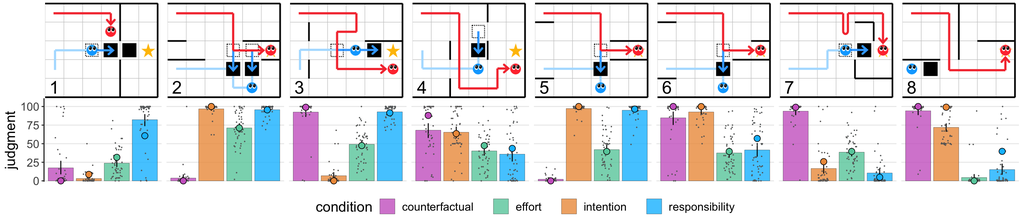

```r
barplot(data.exp1.all, data.exp1.models, labels.exp1)
```

```r
# ggsave(paste0(figures_dir, 'bar.pdf'), width = 16, height = 3.5)
```

### 3.4.2 Simulation models

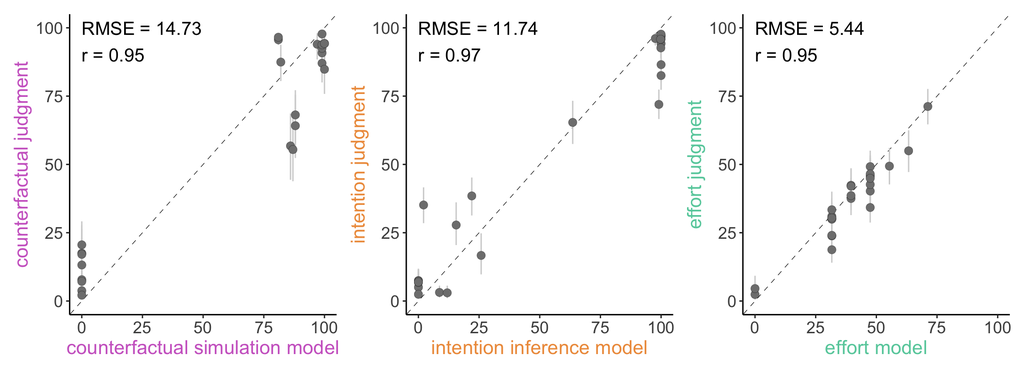

```r
plot.exp1.cf_model = scatterplot(
  data.exp1.cf %>%
    group_by(trial) %>%
    summarise(cf_mean = mean(cf),
              cf_low = smean.cl.boot(cf)[2],
              cf_high = smean.cl.boot(cf)[3]) %>%
    left_join(info.exp1 %>%
                select(trial, cf_model_mean = cf_model),
              by = 'trial') %>%
    mutate(cf_model_low = cf_model_mean,
           cf_model_high = cf_model_mean),
  'cf_model', '<span style="color:orchid3">counterfactual simulation model</span>',
  'cf', '<span style="color:orchid3">counterfactual judgment</span>'
)

plot.exp1.int_model = scatterplot(
  data.exp1.int %>%
    group_by(trial) %>%
    summarise(int_mean = mean(int),
              int_low = smean.cl.boot(int)[2],
              int_high = smean.cl.boot(int)[3]) %>%
    left_join(info.exp1 %>%
                select(trial, int_model_mean = int_model),
              by = 'trial') %>%
    mutate(int_model_low = int_model_mean,
           int_model_high = int_model_mean),
  'int_model', '<span style="color:tan2">intention inference model</span>',
  'int', '<span style="color:tan2">intention judgment</span>'
)

plot.exp1.effort_model = scatterplot(
  data.exp1.effort %>%
    group_by(trial) %>%
    summarise(effort_mean = mean(effort),
              effort_low = smean.cl.boot(effort)[2],
              effort_high = smean.cl.boot(effort)[3]) %>%
    left_join(info.exp1 %>%
                select(trial, effort_model_mean = effort_model),
              by = 'trial') %>%
    mutate(effort_model_low = effort_model_mean,
           effort_model_high = effort_model_mean),
  'effort_model', '<span style="color:aquamarine3">effort model</span>',
  'effort', '<span style="color:aquamarine3">effort judgment</span>'
)

plot.exp1.cf_model + plot.exp1.int_model + plot.exp1.effort_model +
  theme(plot.tag = element_text(size = 24))
```

```r
# ggsave(paste0(figures_dir, 'models.pdf'), width = 11, height = 4)
```

### 3.4.3 Responsibility scatterplots

```r
data.exp1.resp_models = data.exp1.resp %>%
  group_by(trial) %>%
  summarise(resp_mean = mean(resp),
            resp_low = smean.cl.boot(resp)[2],
            resp_high = smean.cl.boot(resp)[3]) %>%
  cbind(fit.exp1.cf %>%
          fitted(newdata = data.exp1.means,
                 re_formula = NA) %>%
            as_tibble() %>%
            select(cf_model = Estimate)) %>%
  cbind(fit.exp1.int %>%
          fitted(newdata = data.exp1.means,
                 re_formula = NA) %>%
            as_tibble() %>%
            select(int_model = Estimate)) %>%
  cbind(fit.exp1.cf_int %>%
          fitted(newdata = data.exp1.means,
                 re_formula = NA) %>%
            as_tibble() %>%
            select(cf_int_model = Estimate)) %>%
  cbind(fit.exp1.cf_effort %>%
          fitted(newdata = data.exp1.means,
                 re_formula = NA) %>%
            as_tibble() %>%
            select(cf_effort_model = Estimate)) %>%
  cbind(fit.exp1.heuristic %>%
          fitted(newdata = data.exp1.means,
                 re_formula = NA) %>%
            as_tibble() %>%
            select(heuristic_model = Estimate)) %>%
  # clip model predictions between 0 and 100
  mutate_at(vars(ends_with('_model')),
            ~ pmax(pmin(.x, 100), 0))
```

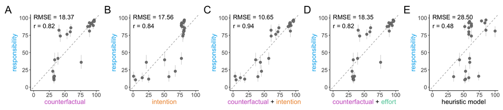

```r
plot.exp1.cf = scatterplot(
  data.exp1.resp_models %>%
    select(trial, resp_mean, resp_low, resp_high,
           cf_model_mean = cf_model,
           cf_model_low = cf_model,
           cf_model_high = cf_model),
  'cf_model', '<span style="color:orchid3">counterfactual</span>',
  'resp', '<span style="color:deepskyblue2">responsibility</span>',
)

plot.exp1.int = scatterplot(
  data.exp1.resp_models %>%
    select(trial, resp_mean, resp_low, resp_high,
           int_model_mean = int_model,
           int_model_low = int_model,
           int_model_high = int_model),
  'int_model', '<span style="color:tan2">intention</span>',
  'resp', '<span style="color:deepskyblue2">responsibility</span>',
)

plot.exp1.cf_int = scatterplot(
  data.exp1.resp_models %>%
    select(trial, resp_mean, resp_low, resp_high,
           cf_int_model_mean = cf_int_model,
           cf_int_model_low = cf_int_model,
           cf_int_model_high = cf_int_model),
  'cf_int_model', '<span style="color:orchid3">counterfactual</span> + <span style="color:tan2">intention</span>',
  'resp', '<span style="color:deepskyblue2">responsibility</span>',
)

plot.exp1.cf_effort = scatterplot(
  data.exp1.resp_models %>%
    select(trial, resp_mean, resp_low, resp_high,
           cf_effort_model_mean = cf_effort_model,
           cf_effort_model_low = cf_effort_model,
           cf_effort_model_high = cf_effort_model),
  'cf_effort_model', '<span style="color:orchid3">counterfactual</span> + <span style="color:aquamarine3">effort</span>',
  'resp', '<span style="color:deepskyblue2">responsibility</span>',
)

plot.exp1.heuristic = scatterplot(
  data.exp1.resp_models %>%
    select(trial, resp_mean, resp_low, resp_high,
           heuristic_model_mean = heuristic_model,
           heuristic_model_low = heuristic_model,
           heuristic_model_high = heuristic_model),
  'heuristic_model', 'heuristic model',
  'resp', '<span style="color:deepskyblue2">responsibility</span>',
)

plot.exp1.cf + plot.exp1.int + plot.exp1.cf_int + plot.exp1.cf_effort + plot.exp1.heuristic +
  plot_layout(nrow = 1) +
  plot_annotation(tag_levels = 'A') &
  theme(plot.tag = element_text(size = 24))
```

```r
# ggsave(paste0(figures_dir, 'responsibility.pdf'), width = 16, height = 3.5)
```

# 4 Experiment 2

```r
data_dir = '../data/experiment2/'
figures_dir = '../figures/experiment2/'
info_dir = '../model/experiments/experiment2/'
```

## 4.1 Data

### 4.1.1 Trial info

```r
trials.exp2 = c(23, 24, 1, 2, 19, 20, 21, 22)

info.exp2 = read_csv(paste0(info_dir, 'models.csv'),
                     show_col_types = F) %>%
  rename(cf_model = cf_success_rate,
         int_model = numerical_intention) %>%
  mutate(outcome = factor(outcome, levels = c('success', 'fail')),
         trial_label = c('2A', '2B', NA, NA, NA, NA, NA, NA,
                          NA, NA, NA, NA, NA, NA, NA, NA,
                          NA, NA, '3A', '3B', '4A', '4B', '1A', '1B')
         ) %>%
  left_join(read_csv(paste0(info_dir, 'heuristics.csv'),
                     show_col_types = F),
            by = 'trial')
```

### 4.1.2 Counterfactual condition

#### 4.1.2.1 Response data

```r
data.exp2.cf = read_csv(paste0(data_dir, 'counterfactual/trials.csv'),
                        show_col_types = F) %>%
  rename(id = workerid) %>%
  drop_na(trial) %>%
  left_join(info.exp2 %>% select(trial, outcome),
            by = 'trial') %>%
  mutate(id = factor(id),
         plot_id = as.factor(as.integer(id)),
         cf_recode = ifelse(outcome == 'success', 100 - cf, cf))
```

Number of participants:

```r
length(unique(data.exp2.cf$id))
```

```
## [1] 50
```

#### 4.1.2.2 Participant data

Participants were asked: “What factors influenced how you decided to respond? Do you have any questions or comments regarding the experiment?”

```r
participants.exp2.cf = read_csv(paste0(data_dir, 'counterfactual/participants.csv'),
                                show_col_types = F) %>%
  rename(id = workerid) %>%
  mutate(id = factor(id)) %>%
  merge(data.exp2.cf %>%
          distinct(id, plot_id),
        by = 'id')

participants.exp2.cf %>%
  select(plot_id, feedback) %>%
  datatable(rownames = F)
```

| plot_id | feedback |
| --- | --- |
| 1 | the amount of moves allowed |
| 2 | if the red player made logical decisions |
| 3 |  |
| 4 | I would count the spaces ahead of time to see if red would make it if blue was not present. |
| 5 | If they could have made it in 10 squares, I said they would have made it. If it were impossible without intervention, I said they would not have. |
| 6 | None I just counted the blocks |
| 7 | If there was a way to still get to the star in time without the blue involved affected how I judged them. |
| 8 | The visual information in front of me including what possible moves the player could do. |
| 9 | I counted the number of moves it would take to reach the star and how the blue ember's moves would affect the red member. |
| 10 | I tried to count the squares to see if the red could finish without the blue helping. If not, then I knew that they needed the blue to be there to succeed. |

[output cut: 40 more lines]

### 4.1.3 Intention condition

#### 4.1.3.1 Response data

```r
data.exp2.int = read_csv(paste0(data_dir, 'intention/trials.csv'),
                         show_col_types = F) %>%
  rename(id = workerid) %>%
  drop_na(trial) %>%
  left_join(info.exp2 %>% select(trial, outcome),
            by = 'trial') %>%
  mutate(id = factor(id),
         plot_id = as.factor(as.integer(id)),
         int_recode = ifelse(outcome == 'success', int, 100 - int))
```

Number of participants:

```r
length(unique(data.exp2.int$id))
```

```
## [1] 50
```

#### 4.1.3.2 Participant data

Participants were asked: “What factors influenced how you decided to respond? Do you have any questions or comments regarding the experiment?”

```r
participants.exp2.int = read_csv(paste0(data_dir, 'intention/participants.csv'),
                                    show_col_types = F) %>%
  rename(id = workerid) %>%
  mutate(id = factor(id)) %>%
  merge(data.exp2.int %>%
          distinct(id, plot_id),
        by = 'id')

participants.exp2.int %>%
  select(plot_id, feedback) %>%
  datatable(rownames = F)
```

| plot_id | feedback |
| --- | --- |
| 1 | Whether the steps of the blue player affect the red player's success and if they attempted to help or hinder. |
| 2 | if they did not help or trying to block the red one, it seemed they were trying to hinder them. |
| 3 | Just my instincts on how I would help or hinder red |
| 4 | Sometimes it was very clear what blue wanted to do. Other times, when blue was a bit slow, I could not be sure, so chose unsure. |
| 5 |  |
| 6 |  |
| 7 | If the action taken by the player controlling the blue character was helpful or unhelpful towards the goal of the red player. |
| 8 | If the blue moved blocks the helped red, it was easy to see they were helping. Sometimes blue moved blocks that hurt red moves and thus hinder their goal. |
| 9 |  |
| 10 | When Blue would move a block to cause Red to take extra steps, I marked blue as hindering. |

[output cut: 40 more lines]

### 4.1.4 Responsibility condition

#### 4.1.4.1 Response data

```r
data.exp2.resp = read_csv(paste0(data_dir, 'responsibility/trials.csv'),
                          show_col_types = F) %>%
  rename(id = workerid) %>%
  drop_na(trial) %>%
  mutate(id = factor(id),
         plot_id = as.factor(as.integer(id)))
```

Number of participants:

```r
length(unique(data.exp2.resp$id))
```

```
## [1] 50
```

#### 4.1.4.2 Participant data

Participants were asked: “What factors influenced how you decided to respond? Do you have any questions or comments regarding the experiment?”

```r
participants.exp2.resp = read_csv(paste0(data_dir, 'responsibility/participants.csv'),
                                  show_col_types = F) %>%
  rename(id = workerid) %>%
  mutate(id = factor(id)) %>%
  merge(data.exp2.resp %>%
          distinct(id, plot_id),
        by = 'id')

participants.exp2.resp %>%
  select(plot_id, feedback) %>%
  datatable(rownames = F)
```

| plot_id | feedback |
| --- | --- |
| 1 | the blue player's actions and the red player's strategy. |
| 2 | I decided my response based on the direct route of the red player and how the blue player responded (either to help the red player or block them from reaching the star). |
| 3 | Not knowing the intention of the players, not being able to see their thought process, if blue still tried to help even if not necessary. |
| 4 | most of it came down to how the blue moved. if the red obviously made a mistake then it was reds fault, but most of the time it was the blue player that determined whether the red won or lost |
| 5 | I looked at how helpful or unhelpful the blue person was in each scenario |
| 6 |  |
| 7 | I considered who's actions contributed to the success or failure of the game, whether it be through a mistake or purposeful malice. |
| 8 | I just thought of if someone was to blame more than the other for either the success or failure |
| 9 |  |
| 10 | wether or not red could have won if blue had not moved the box in red's way. |

[output cut: 40 more lines]

### 4.1.5 Explanation condition

#### 4.1.5.1 Response data

```r
data.exp2.expl_raw = read_csv(paste0(data_dir, 'explanation/trials.csv'),
                          show_col_types = F) %>%
  rename(id = workerid) %>%
  drop_na(trial) %>%
  mutate(id = factor(id),
         plot_id = as.factor(as.integer(id)),
         explanation = str_to_sentence(explanation))
```

Number of participants:

```r
length(unique(data.exp2.expl_raw$id))
```

```
## [1] 50
```

Coded features:

```r
data.exp2.expl = read_csv(paste0(data_dir, 'explanation/trials_coded.csv'),
                              show_col_types = F) %>%
  pivot_longer(cols = -trial,
               names_to = 'feature',
               values_to = 'mentioned') %>%
  mutate(feature = factor(feature, levels = features)) %>%
  left_join(info.exp2 %>% select(trial, trial_label),
            by = 'trial')
```

#### 4.1.5.2 Participant data

Participants were asked: “What factors influenced how you decided to respond? Do you have any questions or comments regarding the experiment?”

```r
participants.exp2.expl = read_csv(paste0(data_dir, 'explanation/participants.csv'),
                                  show_col_types = F) %>%
  rename(id = workerid) %>%
  mutate(id = factor(id)) %>%
  merge(data.exp2.expl_raw %>%
          distinct(id, plot_id),
        by = 'id')

participants.exp2.expl %>%
  select(plot_id, feedback) %>%
  datatable(rownames = F)
```

| plot_id | feedback |
| --- | --- |
| 1 |  |
| 2 | Viewing the movements of each partner |
| 3 | If I thought that the blue player was trying to avoid the passing of the red player, I thought that's why the red didn't get to the star. If the red was able to move around without the blue helping or… |
| 4 | whether blue tried to help or not. whether red identified the shorted path |
| 5 | Thank you! Nothing in particular. I just called it in every way I thought about it. I know it was just a simulation, lol. |
| 6 | I tried to decide if the Red won or failed because of their own actions or the actions of the Blue. Sometimes it was hard to decide. |
| 7 | none |
| 8 | I looked at what Blue's and Red's actions were in each game, and then examined how they contributed to either failing or succeeding. |
| 9 | I just wrote how the red either succeeded or failed based on what I observed. |
| 10 | I just watched what happened and described things how I saw it. So the actions of the two players is what I used. |

[output cut: 40 more lines]

## 4.2 Demographics

```r
participants.exp2.cf %>%
  rbind(participants.exp2.int) %>%
  rbind(participants.exp2.resp) %>%
  rbind(participants.exp2.expl) %>%
  print_demographics()
```

```
## # A tibble: 5 × 2
##   gender         n
##   <chr>      <int>
## 1 Female        98
## 2 Male          93
## 3 Non-binary     7
## 4 trans          1
## 5 <NA>           1
## [1] "age:"
## [1] 36.01508
## [1] 12.37972
## # A tibble: 7 × 2
##   race                              n
##   <chr>                         <int>
## 1 American Indian/Alaska Native     3
## 2 Asian                            18
## 3 Black/African American           16
## 4 Hispanic                          1
## 5 hispanic/latino                   1
## 6 Multiracial                      13
## 7 White                           148
## # A tibble: 3 × 2
##   ethnicity        n
##   <chr>        <int>
## 1 Hispanic        18
## 2 Non-Hispanic   172
## 3 <NA>            10
## [1] "time taken (min):"
## [1] 20.77965
## [1] 12.44945
```

## 4.3 Models

### 4.3.1 Responsibility (blue)

```r
data.exp2.means = info.exp2 %>%
  left_join(data.exp2.cf %>%
              group_by(trial) %>%
              summarise(cf_recode = mean(cf_recode)),
            by = 'trial') %>%
  left_join(data.exp2.int %>%
              group_by(trial) %>%
              summarise(int_recode = mean(int_recode)),
            by = 'trial')

data.exp2.modeling = data.exp2.resp %>%
  select(-resp_red) %>%
  left_join(data.exp2.means, by = 'trial')
```

#### 4.3.1.1 Overall models

Fitting models:

```r
fit.exp2.blue.cf = brm(
  formula = resp_blue ~ 1 + cf_recode + (1 | id),
  data = data.exp2.modeling,
  iter = 2000,
  seed = 1,
  file = "cache/fit.exp2.blue.cf"
)

fit.exp2.blue.int = brm(
  formula = resp_blue ~ 1 + int_recode + (1 | id),
  data = data.exp2.modeling,
  iter = 2000,
  seed = 1,
  file = "cache/fit.exp2.blue.int"
)

fit.exp2.blue.cf_int = brm(
  formula = resp_blue ~ 1 + cf_recode + int_recode + (1 | id),
  data = data.exp2.modeling,
  iter = 2000,
  seed = 1,
  file = "cache/fit.exp2.blue.cf_int"
)

fit.exp2.blue.heuristic = brm(
  formula = resp_blue ~ 1 + outcome + red_steps + blue_steps + box_steps + (1 | id),
  data = data.exp2.modeling,
  iter = 2000,
  seed = 1,
  file = "cache/fit.exp2.blue.heuristic"
)
```

Comparing models with leave-one-out cross-validation:

```r
fit.exp2.blue.cf = add_criterion(
  fit.exp2.blue.cf,
  criterion = "loo",
  reloo = T,
  file = "cache/fit.exp2.blue.cf")

fit.exp2.blue.int = add_criterion(
  fit.exp2.blue.int,
  criterion = "loo",
  reloo = T,
  file = "cache/fit.exp2.blue.int")

fit.exp2.blue.cf_int = add_criterion(
  fit.exp2.blue.cf_int,
  criterion = "loo",
  reloo = T,
  file = "cache/fit.exp2.blue.cf_int")

fit.exp2.blue.heuristic = add_criterion(
  fit.exp2.blue.heuristic,
  criterion = "loo",
  reloo = T,
  file = "cache/fit.exp2.blue.heuristic")

loo_compare(fit.exp2.blue.cf,
            fit.exp2.blue.int,
            fit.exp2.blue.cf_int,
            fit.exp2.blue.heuristic)
```

```
##                         elpd_diff se_diff
## fit.exp2.blue.cf_int       0.0       0.0
## fit.exp2.blue.int        -92.1      13.8
## fit.exp2.blue.cf        -142.1      17.5
## fit.exp2.blue.heuristic -350.5      25.4
```

#### 4.3.1.2 Individual models

```r
fit.exp2.blue.cf_individual = brm(
  formula = resp_blue ~ 1 + cf_recode,
  data = data.exp2.modeling %>%
    filter(plot_id == 1),
  seed = 1,
  save_pars = save_pars(all = T),
  file = "cache/fit.exp2.blue.cf_individual")

fit.exp2.blue.int_individual = brm(
  formula = resp_blue ~ 1 + int_recode,
  data = data.exp2.modeling %>%
    filter(plot_id == 1),
  seed = 1,
  save_pars = save_pars(all = T),
  file = "cache/fit.exp2.blue.int_individual")

fit.exp2.blue.cf_int_individual = brm(
  formula = resp_blue ~ 1 + cf_recode + int_recode,
  data = data.exp2.modeling %>%
    filter(plot_id == 1),
  seed = 1,
  save_pars = save_pars(all = T),
  file = "cache/fit.exp2.blue.cf_int_individual")

fit.exp2.blue.heuristic_individual = brm(
  formula = resp_blue ~ 1 + outcome + red_steps + blue_steps + box_steps,
  data = data.exp2.modeling %>%
    filter(plot_id == 1),
  seed = 1,
  save_pars = save_pars(all = T),
  file = "cache/fit.exp2.blue.heuristic_individual")

# update model fits for each participant
individual_fits.exp2 = data.exp2.modeling %>%
  group_by(plot_id) %>%
  nest() %>%
  ungroup() %>%
  mutate(fit_cf = map(.x = data,
                            .f = ~ update(fit.exp2.blue.cf_individual,
                                          newdata = .x,
                                          seed = 1)),
         fit_int = map(.x = data,
                            .f = ~ update(fit.exp2.blue.int_individual,
                                          newdata = .x,
                                          seed = 1)),
         fit_cf_int = map(.x = data,
                            .f = ~ update(fit.exp2.blue.cf_int_individual,
                                          newdata = .x,
                                          seed = 1)),
         fit_heuristic = map(.x = data,
                            .f = ~ update(fit.exp2.blue.heuristic_individual,
                                          newdata = .x,
                                          seed = 1))) %>%
  mutate(fit_cf = map(.x = fit_cf,
                            .f = ~ add_criterion(.x, criterion = "loo",
                                                 moment_match = T)),
         fit_int = map(.x = fit_int,
                            .f = ~ add_criterion(.x, criterion = "loo",
                                                 moment_match = T)),
         fit_cf_int = map(.x = fit_cf_int,
                            .f = ~ add_criterion(.x, criterion = "loo",
                                                 moment_match = T)),
         fit_heuristic = map(.x = fit_heuristic,
                            .f = ~ add_criterion(.x, criterion = "loo",
                                                 moment_match = T)),
         model_comparison = pmap(.l = list(cf = fit_cf,
                                           int = fit_int,
                                           cf_int = fit_cf_int,
                                           heuristic = fit_heuristic),
                                 .f = ~ loo_compare(..1, ..2, ..3, ..4)),
         best_model = map_chr(.x = model_comparison,
                              .f = ~ rownames(.) %>%
                                .[1]),
         best_model = factor(best_model,
                             levels = c("..1", "..2", "..3", "..4"),
                             labels = c("cf",
                                        "int",
                                        "cf_int",
                                        "heuristic")))

save(list = c("individual_fits.exp2"),
     file = 'cache/individual_fits.exp2.RData')
```

```r
load(file = 'cache/individual_fits.exp2.RData')

individual_fits.exp2 %>%
  count(best_model) %>%
  arrange(desc(n))
```

```
## # A tibble: 4 × 2
##   best_model     n
##   <fct>      <int>
## 1 cf_int        26
## 2 int           15
## 3 cf             7
## 4 heuristic      2
```

### 4.3.2 Responsibility (red)

```r
fit.exp2.red = brm(
  formula = resp_red ~ 1 + resp_blue + (1 | id),
  data = data.exp2.resp,
  iter = 2000,
  seed = 1,
  file = "cache/fit.exp2.red"
)
```

## 4.4 Figures

```r
data.exp2.all = data.exp2.resp %>%
  select(-id) %>%
  pivot_longer(cols = starts_with('resp'),
               names_to = 'condition',
               values_to = 'judgment') %>%
  rbind(data.exp2.cf %>%
         select(plot_id, trial, judgment = cf) %>%
         mutate(condition = 'cf')) %>%
  rbind(data.exp2.int %>%
         select(plot_id, trial, judgment = int) %>%
         mutate(condition = 'int')) %>%
  mutate(condition = factor(condition, levels = conditions)) %>%
  left_join(info.exp2 %>% select(trial, trial_label),
            by = 'trial') %>%
  filter(trial %in% trials.exp2) %>%
  mutate(trial = as.integer(factor(trial, levels = trials.exp2)))

data.exp2.models = info.exp2 %>%
  select(trial, cf_model, int_model) %>%
  cbind(fit.exp2.blue.cf_int %>%
          fitted(newdata = data.exp2.means,
                 re_formula = NA) %>%
          as_tibble() %>%
          select(resp_blue_model = Estimate)) %>%
  left_join(data.exp2.resp %>%
              cbind(fit.exp2.red %>%
                      fitted(newdata = data.exp2.resp) %>%
                      as_tibble()) %>%
              group_by(trial) %>%
              summarise(resp_red_model = mean(Estimate)),
            by = 'trial') %>%
  rename_with(~ sub('_model', '', .x)) %>%
  filter(trial %in% trials.exp2) %>%
  pivot_longer(cols = -trial,
               names_to = 'condition',
               values_to = 'prediction') %>%
  mutate(condition = factor(condition, levels = conditions),
         trial = as.integer(factor(trial, levels = trials.exp2)))
```

```r
labels.exp2 = data.frame(trial = trials.exp2) %>%
  mutate(grob = map(.x = trial,
                    .f = ~ readPNG(paste0(figures_dir, 'trial_stills/',
                                          .x, '.png'))),
         trial = as.integer(factor(trial,
                                   levels = trials.exp2)))
```

### 4.4.1 Barplot

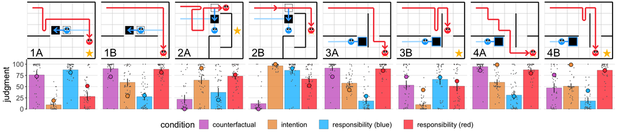

```r
barplot(data.exp2.all, data.exp2.models, labels.exp2)
```

```r
# ggsave(paste0(figures_dir, 'bar.pdf'), width = 16, height = 3.5)
```

### 4.4.2 Simulation models

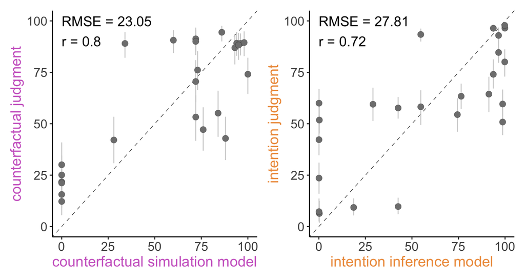

```r
plot.exp2.cf_model = scatterplot(
  data.exp2.cf %>%
    group_by(trial) %>%
    summarise(cf_mean = mean(cf),
              cf_low = smean.cl.boot(cf)[2],
              cf_high = smean.cl.boot(cf)[3]) %>%
    left_join(info.exp2 %>%
                select(trial, cf_model_mean = cf_model),
              by = 'trial') %>%
    mutate(cf_model_low = cf_model_mean,
           cf_model_high = cf_model_mean),
  'cf_model', '<span style="color:orchid3">counterfactual simulation model</span>',
  'cf', '<span style="color:orchid3">counterfactual judgment</span>'
)

plot.exp2.int_model = scatterplot(
  data.exp2.int %>%
    group_by(trial) %>%
    summarise(int_mean = mean(int),
              int_low = smean.cl.boot(int)[2],
              int_high = smean.cl.boot(int)[3]) %>%
    left_join(info.exp2 %>%
                select(trial, int_model_mean = int_model),
              by = 'trial') %>%
    mutate(int_model_low = int_model_mean,
           int_model_high = int_model_mean),
  'int_model', '<span style="color:tan2">intention inference model</span>',
  'int', '<span style="color:tan2">intention judgment</span>'
)

plot.exp2.cf_model + plot.exp2.int_model +
  theme(plot.tag = element_text(size = 24))
```

```r
# ggsave(paste0(figures_dir, 'models.pdf'), width = 7.5, height = 4)
```

### 4.4.3 Responsibility scatterplots

```r
data.exp2.resp_blue_models = data.exp2.resp %>%
  group_by(trial) %>%
  summarise(resp_mean = mean(resp_blue),
            resp_low = smean.cl.boot(resp_blue)[2],
            resp_high = smean.cl.boot(resp_blue)[3]) %>%
  cbind(fit.exp2.blue.cf %>%
          fitted(newdata = data.exp2.means,
                 re_formula = NA) %>%
            as_tibble() %>%
            select(cf_model = Estimate)) %>%
  cbind(fit.exp2.blue.int %>%
          fitted(newdata = data.exp2.means,
                 re_formula = NA) %>%
            as_tibble() %>%
            select(int_model = Estimate)) %>%
  cbind(fit.exp2.blue.cf_int %>%
          fitted(newdata = data.exp2.means,
                 re_formula = NA) %>%
            as_tibble() %>%
            select(cf_int_model = Estimate)) %>%
  cbind(fit.exp2.blue.heuristic %>%
          fitted(newdata = data.exp2.means,
                 re_formula = NA) %>%
            as_tibble() %>%
            select(heuristic_model = Estimate)) %>%
  # clip model predictions between 0 and 100
  mutate_at(vars(ends_with('_model')),
            ~ pmax(pmin(.x, 100), 0))
```

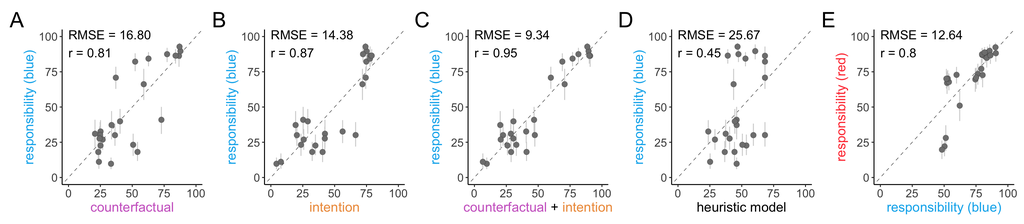

```r
# responsibility for blue
plot.exp2.blue.cf = scatterplot(
  data.exp2.resp_blue_models %>%
    select(trial, resp_mean, resp_low, resp_high,
           cf_model_mean = cf_model,
           cf_model_low = cf_model,
           cf_model_high = cf_model),
  'cf_model', '<span style="color:orchid3">counterfactual</span>',
  'resp', '<span style="color:deepskyblue2">responsibility (blue)</span>',
)

plot.exp2.blue.int = scatterplot(
  data.exp2.resp_blue_models %>%
    select(trial, resp_mean, resp_low, resp_high,
           int_model_mean = int_model,
           int_model_low = int_model,
           int_model_high = int_model),
  'int_model', '<span style="color:tan2">intention</span>',
  'resp', '<span style="color:deepskyblue2">responsibility (blue)</span>',
)

plot.exp2.blue.cf_int = scatterplot(
  data.exp2.resp_blue_models %>%
    select(trial, resp_mean, resp_low, resp_high,
           cf_int_model_mean = cf_int_model,
           cf_int_model_low = cf_int_model,
           cf_int_model_high = cf_int_model),
  'cf_int_model', '<span style="color:orchid3">counterfactual</span> + <span style="color:tan2">intention</span>',
  'resp', '<span style="color:deepskyblue2">responsibility (blue)</span>',
)

plot.exp2.blue.heuristic = scatterplot(
  data.exp2.resp_blue_models %>%
    select(trial, resp_mean, resp_low, resp_high,
           heuristic_model_mean = heuristic_model,
           heuristic_model_low = heuristic_model,
           heuristic_model_high = heuristic_model),
  'heuristic_model', 'heuristic model',
  'resp', '<span style="color:deepskyblue2">responsibility (blue)</span>',
)

# responsibility for red
plot.exp2.red = scatterplot(
  data.exp2.resp %>%
    group_by(trial) %>%
    summarise(resp_mean = mean(resp_red),
              resp_low = smean.cl.boot(resp_red)[2],
              resp_high = smean.cl.boot(resp_red)[3]) %>%
    left_join(data.exp2.resp %>%
                cbind(fit.exp2.red %>%
                        fitted(newdata = data.exp2.resp) %>%
                        as_tibble()) %>%
                group_by(trial) %>%
                summarise(model_mean = mean(Estimate)),
              by = 'trial') %>%
    mutate(model_low = model_mean,
           model_high = model_mean),
  'model', '<span style="color:deepskyblue2">responsibility (blue)</span>',
  'resp', '<span style="color:brown1">responsibility (red)</span>',
)

plot.exp2.blue.cf + plot.exp2.blue.int + plot.exp2.blue.cf_int + plot.exp2.blue.heuristic + plot.exp2.red +
  plot_layout(nrow = 1) +
  plot_annotation(tag_levels = 'A') &
  theme(plot.tag = element_text(size = 24))
```

```r
# ggsave(paste0(figures_dir, 'responsibility.pdf'), width = 16, height = 3.5)
```

### 4.4.4 Explanations

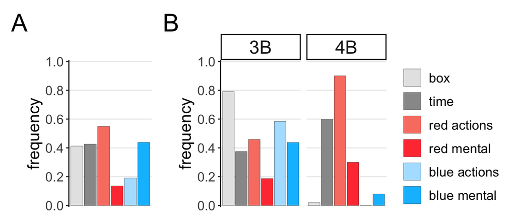

```r
plot.exp2.expl_aggregate = ggplot(data = data.exp2.expl,
                                  mapping = aes(x = feature,
                                                y = mentioned,
                                                fill = feature)) +
  stat_summary(fun = "mean",
               geom = "bar",
               color = "black",
               size = 0.1)

plot.exp2.expl_subset = ggplot(data = data.exp2.expl %>%
                                 filter(trial %in% c(20, 22)),
                               mapping = aes(x = feature,
                                             y = mentioned,
                                             fill = feature)) +
  stat_summary(fun = "mean",
               geom = "bar",
               color = "black",
               size = 0.1) +
  facet_wrap(~ trial_label, nrow = 1)

plot.exp2.expl_aggregate + plot.exp2.expl_subset +
  plot_annotation(tag_levels = 'A') +
  plot_layout(nrow = 1, widths = c(1, 2),
              guides = 'collect') &
  scale_fill_manual(values = feature_colors,
                    labels = feature_labels) &
  scale_y_continuous(name = 'frequency',
                     limits = c(0, 1),
                     breaks = seq(0, 1, 0.2),
                     expand = expansion(mult = 0.01)) &
  guides(fill = guide_legend(byrow = T)) &
  theme(text = element_text(size = 16),
        legend.position = 'right',
        legend.title = element_blank(),
        legend.spacing.y = unit(0.2, 'cm'),
        axis.title.x = element_blank(),
        axis.text.x = element_blank(),
        axis.line.x = element_blank(),
        axis.ticks.x = element_blank(),
        strip.text = element_text(size = 18),
        panel.grid.major.y = element_line(),
        plot.tag = element_text(size = 24))
```

```r
# ggsave(paste0(figures_dir, 'explanation.pdf'), width = 7, height = 3)
```